# DYRESM Simulations

### Summary

DYRESM parameters were adjusted to minimize RMSE of stratification indicies for 2011 and 2014. Once optimized, the parameters were averaged and used to predict unmixed 2012 and 2013, and later combined with the bubble plume module to predict mixed 2012 and 2013. The number of plume sources varied to minimize RMSE of the temperature range observed during plume mixing to that observed during GELI mixing, where the period of comparison was restricted to the period of GELI mixing.

### Parameters

As a starting point, parameters used in Gaeta et al simulations (2003-2008) were averaged, and are refered to as “JSR”. Five other variations of the JSR parameter set were tested. The top three performers were SET1, SET2, and JSR (in that order). In general, JSR predicted cooler surface waters and less water column stability than observed, so subsequent parameter sets attempted to increase heat content of the lake. Differences between these parameter sets are highlighted below.

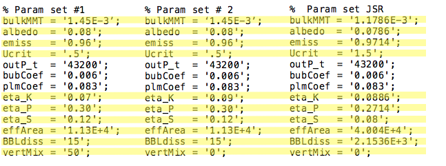

### Simulating 2011 and 2014

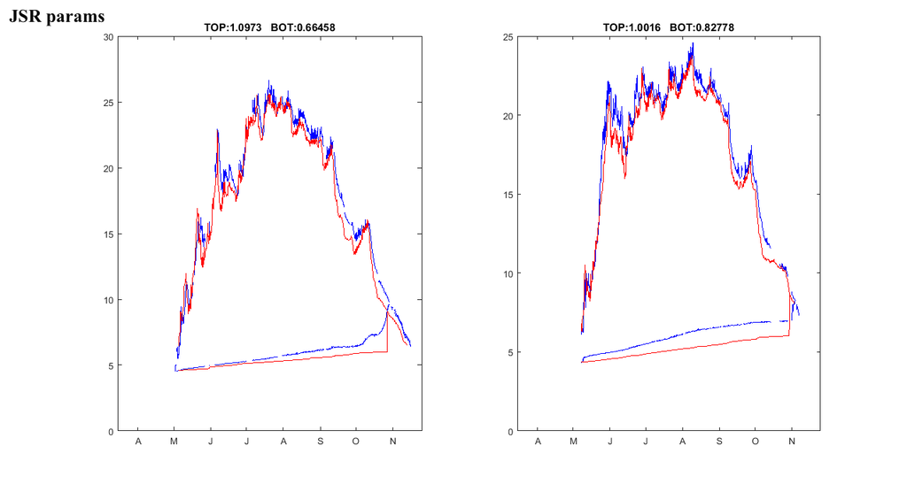

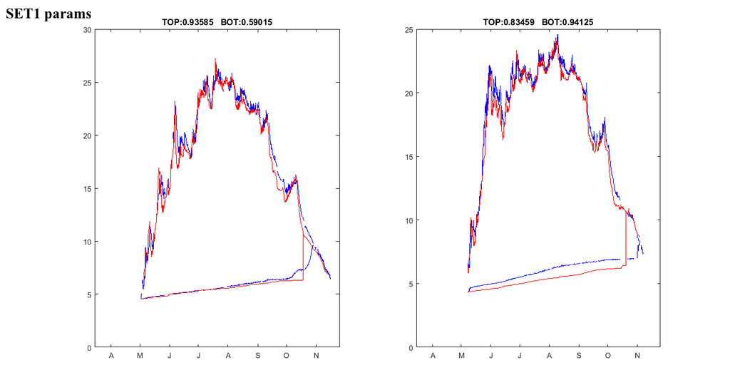

JSR also performs better in prediction of metalimnion and thermocline depths, but SET1 and SET2 better predict Schmidt Stability:

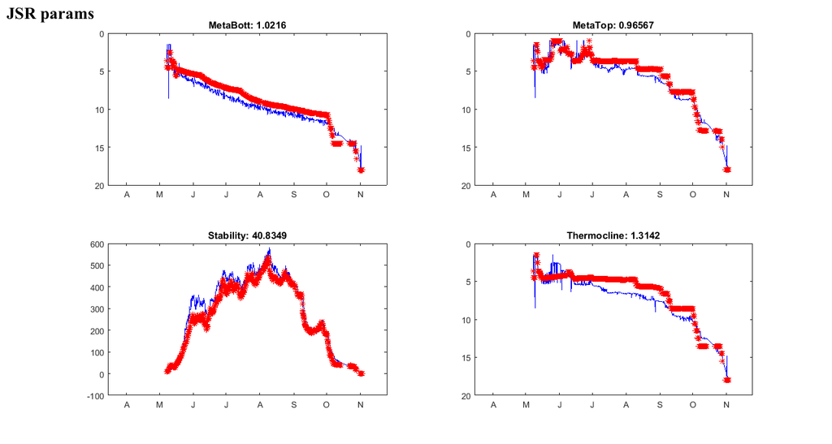

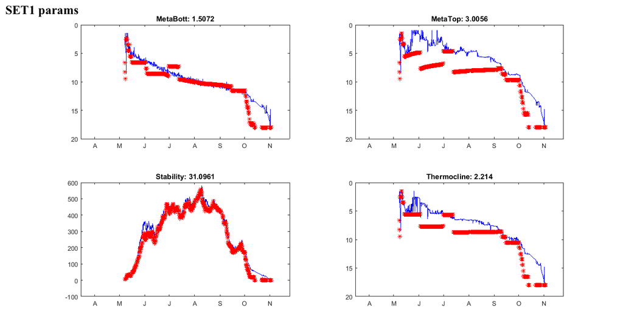

### Plume Mixing 2012 and 2013

At flow rates of 10 L s-1, SET1 parameters best simulate the temperature range observed during GELI mixing at 12 and 18 plume sources for 2012 and 2013, respectively. For JSR parameters, this temperature range is best simulated by 14 and 16 plume sources.

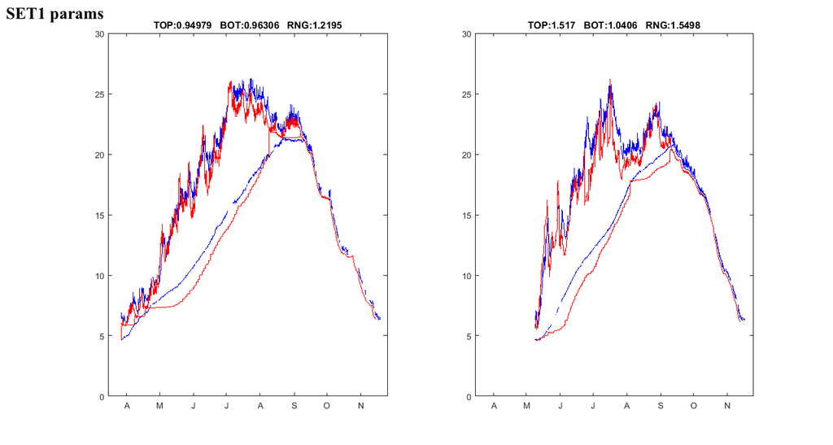

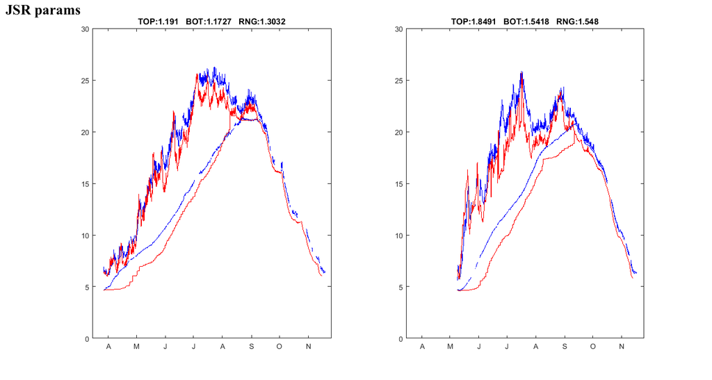

Note worthy is the distribution of temperature throughout the lake during GELI and plume mixing. The reservoir of heat in the “epilimnion” during GELI mixing is much greater than during simulated plume mixing as illustrated below. Is this difference real or an artifact of the simulation? If real then it needs explanation.

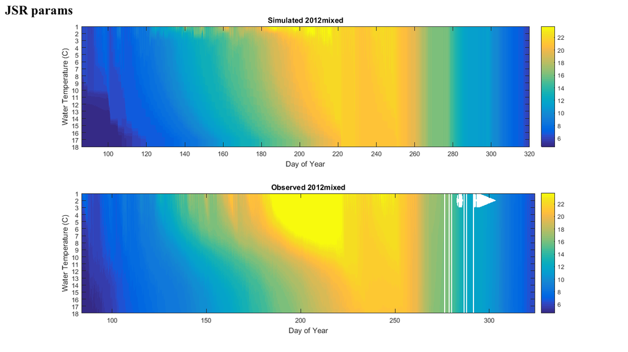

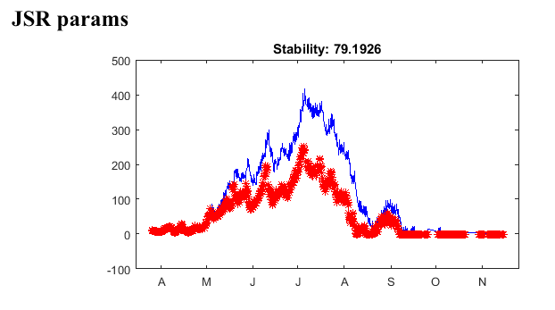